# Scenario: Exclusion Zone Implementation @ Ballard

Describing the model run when an exclusion zone management strategy is implemented at the Ballard Locks

October 23, 2024

### The Narrative

This Model Run is for a scenario where managers in the Gauntlet enact an “Exclusion Zone” management strategy. In this strategy, all pinnipeds that cross into the Gauntlet area when salmon are present in the Gauntlet are targeted for removal. We assume that managers are able to effectively remove a percentage of pinnipeds in the area. Their efficiency is dependent on the total density of pinnipeds.

### Run the Model

```r
zone_efficiency <- 0.8
zone_steepness <- 5
scenario <- "Zone"
scenario_sealion <- "Zone"
harvest_open <- start_loop
harvest_close <- end_loop
steepness_H <- NA
accuracy <- NA
availability <- NA
efficiency <- availability * accuracy
```

### Description of Parameterization

This scenario is focused on the effects of implementing an Exclusion Zone management strategy in the Ballard Locks. Under this strategy, both seals and sea lions are removed from the Gauntlet by managers throughout all days of the model run. The proportion of pinnipeds that are removed is governed by an efficiency term which describes the asymptote of the type II response between the number of pinnipeds at the Gauntlet and the proportion of individuals removed. That response is shown below:

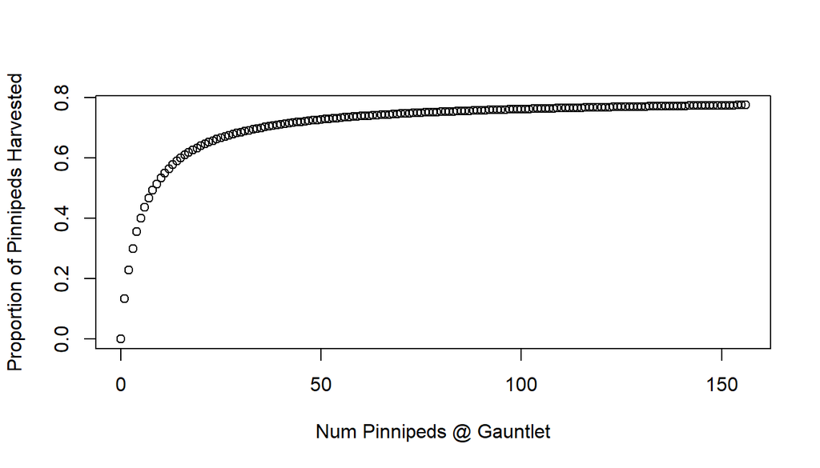

In this parameterization, many more pinnipeds are removed from the system than under incidental or boat-based take only.

Pinnipeds Removed

| Pv | Ej | Zc |
| --- | --- | --- |
| 60 | 0 | 2 |

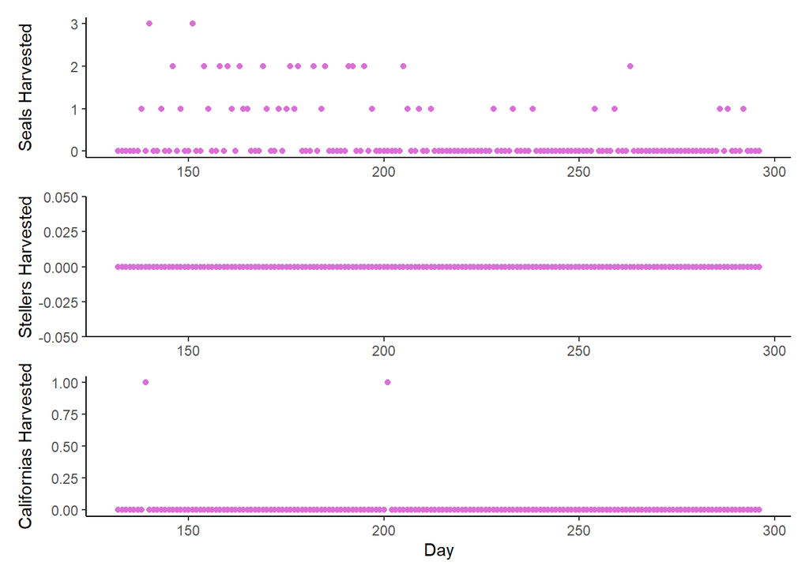

Because of the intensive removals, this scenario has an impact on pinniped behavior and presence at the Gauntlet.

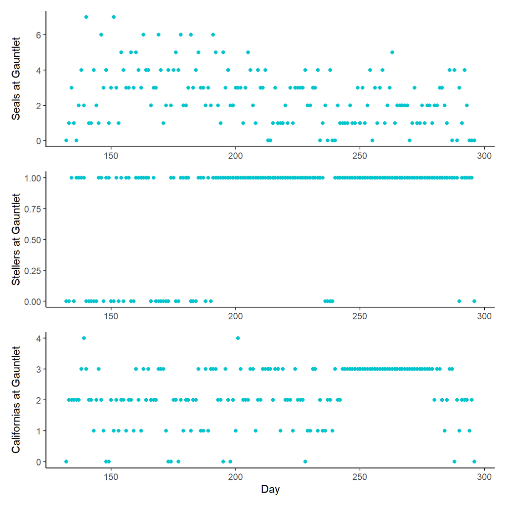

In the below plots, you can see the impact of removals on the learning process of individual harbor seals as their probability of going to the Gauntlet is reduced through exposure to harvest risk.

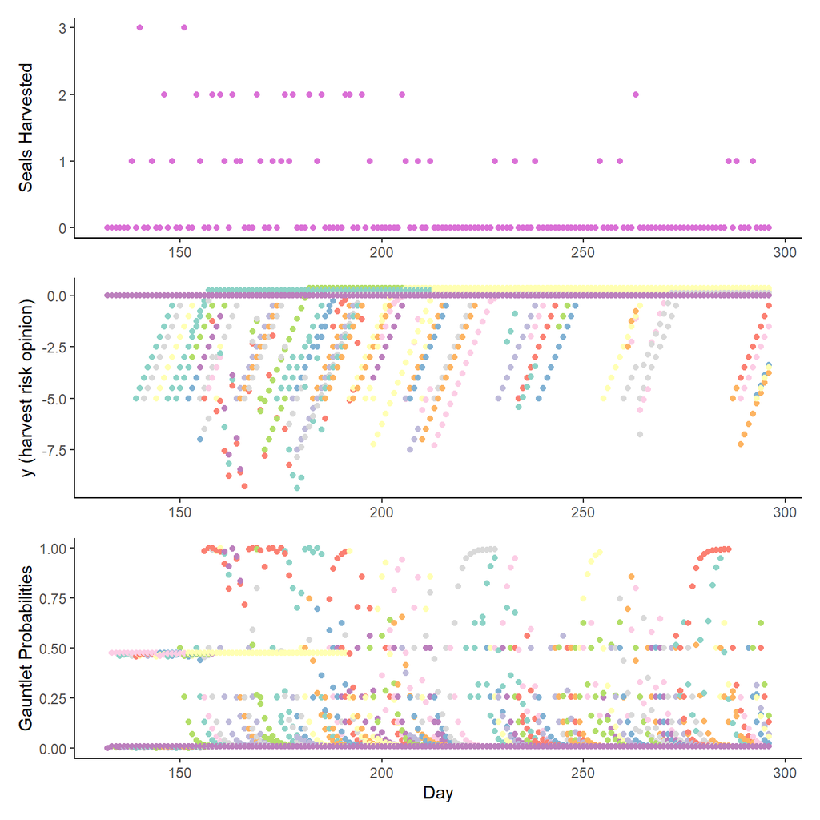

### Salmon Response

The salmon response under this parameterization is as follows:

|  | Sockeye | Chinook | Coho |
| --- | --- | --- | --- |
| Escape | 65302 | 2909 | 9873 |
| Catch | 0 | 1621 | 4543 |
| Predated | 3547 | 4641 | 2703 |

The total number of salmon that are consumed by pinnipeds is reduced in this scenario for all three salmon runs.

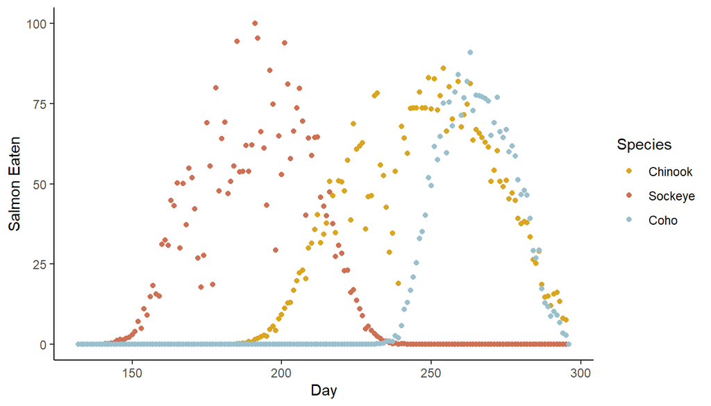

### Parameter Table

|  | Value |
| --- | --- |
| num_seals | 150.0 |
| num_zc | 5.0 |
| num_ej | 1.0 |
| zone_efficiency | 0.8 |
| zone_steepness | 5.0 |
| harvest_open | 132.0 |
| harvest_close | 296.0 |
| sockeye_residence | 3.0 |
| chinook_residence | 66.0 |
| coho_residence | 10.0 |